# Querying the WsprDaemon Timescale Database using R and SQL

Andi Fugard M0INF (almost@gmail.com, @[inductivestep](https://twitter.com/InductiveStep))

05 January 2021

This short Markdown file shows how to query the [WsprDaemon Timescale Database](http://wsprdaemon.org/timebasedb.html) using R and SQL.

## Setup packages

```r
library(RPostgres)
library(DBI)
library(tidyverse)
library(DT)
library(knitr)
library(fuzzyjoin)

dt_options <- list(pageLength=7, scrollX = "400px")
```

## Connect to the database

The settings are available [over here](http://wsprdaemon.org/ewExternalFiles/Timescale_wsprdaemon_database_queries_and_APIs_V2.pdf).

```r
db_name <- "wsprnet"
db_host <- "logs2.wsprdaemon.org"
db_user <- "wdread"
db_password <- "JTWSPR2008"
db_con <- dbConnect(RPostgres::Postgres(),
                    dbname = db_name,
                    host = db_host,
                    user = db_user,
                    password = db_password)
```

Check if it worked:

```r
dbListTables(db_con)
```

```
## [1] "spots"
```

Yes!

Let’s try an example based on SQL from the WsprDaemon Timescale Databases Notes ([Version 2.0 November 2020](http://wsprdaemon.org/ewExternalFiles/Timescale_wsprdaemon_database_queries_and_APIs_V2.pdf)):

```r
res <- dbSendQuery(db_con,
  "SELECT * FROM spots
   ORDER BY wd_time DESC
   LIMIT 20;")
```

```r
dbFetch(res) %>%
  datatable(options = dt_options)
```

|  | wd_time | Spotnum | Date | Reporter | ReporterGrid | dB | MHz | CallSign | Grid | Power | Drift | distance | azimuth | Band | version | code | wd_band | wd_c2_noise | wd_rms_noise | wd_rx_az | wd_rx_lat | wd_rx_lon | wd_tx_az | wd_tx_lat | wd_tx_lon | wd_v_lat | wd_v_lon |
| --- | --- | --- | --- | --- | --- | --- | --- | --- | --- | --- | --- | --- | --- | --- | --- | --- | --- | --- | --- | --- | --- | --- | --- | --- | --- | --- | --- |
| 1 | 2021-01-05T20:07:00Z | 2715678749 | 1609877220 | VK7JJ/3 | QE38lr | 20 | 144.489 | VK7JJ/2 | QE38lr | 20 | 0 | 28 | 180 | 144 | fake | 1 | 2 | -999.9 | -999.9 | 0 | -41.271 | 146.958 | 0 | -41.271 | 146.958 | -41.271 | 146.958 |
| 2 | 2021-01-05T20:04:00Z | 2715674819 | 1609877040 | VK7JJ | QE38 | 20 | 144.489 | AI6VN/KH6 | BL10rx | 20 | 0 | 9058 | 219 | 144 | fake | 2 | 2 | -999.9 | -999.9 | 52 | -41.5 | 147 | 219 | 20.979 | -156.542 | 53.882 | -82.79 |
| 3 | 2021-01-05T13:20:00Z | 2716857347 | 1609852800 | N6WXD | DM12lx | 13 | 10.140291 | K6RRP | DM12lw | 33 | 0 | 5 | 0 | 10 |  | 1 | 30 | -999.9 | -999.9 | 180 | 32.979 | -117.042 | 0 | 32.938 | -117.042 | 32.979 | -117.042 |
| 4 | 2021-01-05T13:20:00Z | 2716857348 | 1609852800 | N6WXD | DM12lx | -22 | 3.570191 | KE6ZIQ | DM09 | 23 | 0 | 745 | 165 | 3 |  | 1 | 80 | -999.9 | -999.9 | 347 | 32.979 | -117.042 | 166 | 39.5 | -119 | 39.5 | -119 |
| 5 | 2021-01-05T13:20:00Z | 2716857349 | 1609852800 | N6WXD | DM12lx | 4 | 3.570175 | K6RRP | DM12lw | 33 | 0 | 5 | 0 | 3 |  | 1 | 80 | -999.9 | -999.9 | 180 | 32.979 | -117.042 | 0 | 32.938 | -117.042 | 32.979 | -117.042 |
| 6 | 2021-01-05T13:20:00Z | 2716857352 | 1609852800 | N6WXD | DM12lx | -19 | 1.838108 | W6VJT | DM62 | 23 | 0 | 937 | 276 | 1 |  | 1 | 160 | -999.9 | -999.9 | 91 | 32.979 | -117.042 | 276 | 32.5 | -107 | 32.983 | -116.09 |
| 7 | 2021-01-05T13:18:00Z | 2716853229 | 1609852680 | JJ1BDX | PM95tp | -27 | 7.040103 | W4WLO | EM50vj | 33 | 0 | 11133 | 322 | 7 |  | 1 | 40 | -999.9 | -999.9 | 40 | 35.646 | 139.625 | 322 | 30.396 | -88.208 | 35.646 | 139.625 |
| 8 | 2021-01-05T13:18:00Z | 2716853234 | 1609852680 | JJ1BDX | PM95tp | -22 | 7.040023 | AG6RK | CM97cf | 37 | 0 | 8358 | 304 | 7 |  | 1 | 40 | -999.9 | -999.9 | 55 | 35.646 | 139.625 | 304 | 37.229 | -121.792 | 37.229 | -121.792 |
| 9 | 2021-01-05T13:18:00Z | 2716853249 | 1609852680 | WB6JHI | CM97af | -19 | 7.040015 | AG6RK | CM97cf | 37 | 0 | 15 | 270 | 7 | 2.2.0-rc15 | 1 | 40 | -999.9 | -999.9 | 90 | 37.229 | -121.958 | 270 | 37.229 | -121.792 | 37.229 | -121.875 |
| 10 | 2021-01-05T13:18:00Z | 2716853250 | 1609852680 | WB6JHI | CM97af | -18 | 7.040074 | KD4LOL | EL99 | 37 | 0 | 3866 | 294 | 7 | 2.2.0-rc15 | 1 | 40 | -999.9 | -999.9 | 91 | 37.229 | -121.958 | 294 | 29.5 | -81 | 37.233 | -121.032 |

[output cut: 10 more lines]

Yes – works.

```r
dbClearResult(res)
```

## Grab a time range

### All transmisions

Let’s try one day’s worth of data – reception reports of M0INF. There’s a SQL quirk below. Variable names which aren’t all in lower case (such as `CallSign`) have to be referenced using double quotation marks; the quotes are escaped using the backslash. String literals like a callsign use single quotes.

```r
one_day <- dbSendQuery(db_con,
  "SELECT * FROM spots
   WHERE \"CallSign\" = 'M0INF'
         AND wd_time >= '2021-01-03T00:00:00Z'
         AND wd_time < '2021-01-04T00:00:00Z';")
```

This fetches the data to a data frame:

```r
the_dat <- dbFetch(one_day)
dbClearResult(one_day)
the_dat %>%
  datatable(options = dt_options)
```

|  | wd_time | Spotnum | Date | Reporter | ReporterGrid | dB | MHz | CallSign | Grid | Power | Drift | distance | azimuth | Band | version | code | wd_band | wd_c2_noise | wd_rms_noise | wd_rx_az | wd_rx_lat | wd_rx_lon | wd_tx_az | wd_tx_lat | wd_tx_lon | wd_v_lat | wd_v_lon |
| --- | --- | --- | --- | --- | --- | --- | --- | --- | --- | --- | --- | --- | --- | --- | --- | --- | --- | --- | --- | --- | --- | --- | --- | --- | --- | --- | --- |
| 1 | 2021-01-03T23:56:00Z | 2712590891 | 1609718160 | GB0SNB/SDR | JO01dq | -25 | 14.097096 | M0INF | IO91wn | 33 | 0 | 32 | 64 | 14 | 1.3 Kiwi | 1 | 20 | -999.9 | -999.9 | 244 | 51.688 | 0.292 | 64 | 51.562 | -0.125 | 51.688 | 0.292 |
| 2 | 2021-01-03T22:48:00Z | 2712485472 | 1609714080 | GB0SNB/SDR | JO01dq | -25 | 14.097096 | M0INF | IO91wn | 33 | 0 | 32 | 64 | 14 | 1.3 Kiwi | 1 | 20 | -999.9 | -999.9 | 244 | 51.688 | 0.292 | 64 | 51.562 | -0.125 | 51.688 | 0.292 |
| 3 | 2021-01-03T23:20:00Z | 2712536310 | 1609716000 | GB0SNB/SDR | JO01dq | -24 | 14.097096 | M0INF | IO91wn | 33 | 0 | 32 | 64 | 14 | 1.3 Kiwi | 1 | 20 | -999.9 | -999.9 | 244 | 51.688 | 0.292 | 64 | 51.562 | -0.125 | 51.688 | 0.292 |
| 4 | 2021-01-03T23:44:00Z | 2712572034 | 1609717440 | GB0SNB/SDR | JO01dq | -24 | 14.097096 | M0INF | IO91wn | 33 | 0 | 32 | 64 | 14 | 1.3 Kiwi | 1 | 20 | -999.9 | -999.9 | 244 | 51.688 | 0.292 | 64 | 51.562 | -0.125 | 51.688 | 0.292 |
| 5 | 2021-01-03T23:32:00Z | 2712554155 | 1609716720 | GB0SNB/SDR | JO01dq | -19 | 14.097096 | M0INF | IO91wn | 33 | 0 | 32 | 64 | 14 | 1.3 Kiwi | 1 | 20 | -999.9 | -999.9 | 244 | 51.688 | 0.292 | 64 | 51.562 | -0.125 | 51.688 | 0.292 |
| 6 | 2021-01-03T22:38:00Z | 2712468910 | 1609713480 | GB0SNB/SDR | JO01dq | -26 | 14.097096 | M0INF | IO91wn | 33 | 0 | 32 | 64 | 14 | 1.3 Kiwi | 1 | 20 | -999.9 | -999.9 | 244 | 51.688 | 0.292 | 64 | 51.562 | -0.125 | 51.688 | 0.292 |
| 7 | 2021-01-03T19:48:00Z | 2712199589 | 1609703280 | GB0SNB/SDR | JO01dq | -25 | 14.097096 | M0INF | IO91wn | 33 | 0 | 32 | 64 | 14 | 1.3 Kiwi | 1 | 20 | -999.9 | -999.9 | 244 | 51.688 | 0.292 | 64 | 51.562 | -0.125 | 51.688 | 0.292 |
| 8 | 2021-01-03T22:14:00Z | 2712431110 | 1609712040 | GB0SNB/SDR | JO01dq | -26 | 14.097096 | M0INF | IO91wn | 33 | 0 | 32 | 64 | 14 | 1.3 Kiwi | 1 | 20 | -999.9 | -999.9 | 244 | 51.688 | 0.292 | 64 | 51.562 | -0.125 | 51.688 | 0.292 |
| 9 | 2021-01-03T21:36:00Z | 2712370530 | 1609709760 | GB0SNB/SDR | JO01dq | -25 | 14.097096 | M0INF | IO91wn | 33 | 0 | 32 | 64 | 14 | 1.3 Kiwi | 1 | 20 | -999.9 | -999.9 | 244 | 51.688 | 0.292 | 64 | 51.562 | -0.125 | 51.688 | 0.292 |
| 10 | 2021-01-03T21:50:00Z | 2712394320 | 1609710600 | GB0SNB/SDR | JO01dq | -26 | 14.097096 | M0INF | IO91wn | 33 | 0 | 32 | 64 | 14 | 1.3 Kiwi | 1 | 20 | -999.9 | -999.9 | 244 | 51.688 | 0.292 | 64 | 51.562 | -0.125 | 51.688 | 0.292 |

[output cut: 153 more lines]

Now plot:

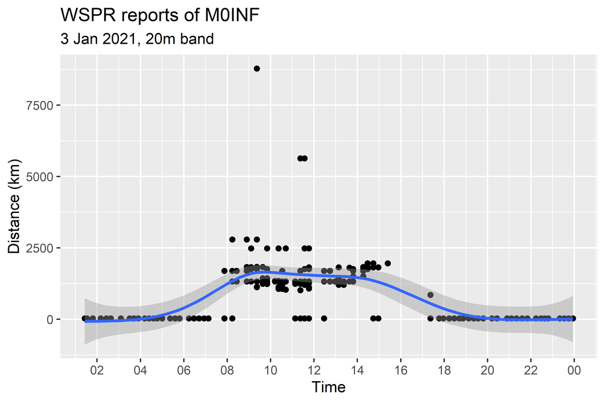

```r
the_dat %>%
  ggplot(aes(wd_time, distance)) +
  geom_point() +
  geom_smooth(method = "gam",
              formula = y ~ s(x, k = 20)) +
  labs(x = "Time", y = "Distance (km)",
       title = "WSPR reports of M0INF",
       subtitle = "3 Jan 2021, 20m band") +
  scale_x_datetime(date_breaks = "2 hour", date_labels = "%H")
```

### Both transmissions and reception reports

Let’s do the same again; however, now with reception reports both by and of M0INF.

```r
one_day_send_receive <- dbSendQuery(db_con,
  "SELECT * FROM spots
   WHERE (\"CallSign\" = 'M0INF' OR \"Reporter\" = 'M0INF')
   AND wd_time >= '2021-01-03T00:00:00Z'
   AND wd_time <  '2021-01-04T00:00:00Z';")
```

```r
the_dat_send_rec <- dbFetch(one_day_send_receive)
dbClearResult(one_day_send_receive)
```

```r
the_dat_send_rec <- the_dat_send_rec %>%
  mutate(Direction = ifelse(Reporter == "M0INF",
                            "Rx by M0INF",
                            "Tx by M0INF"))
```

The graph is a bit crowded so the y-axis is on the $\log_{10}$ scale.

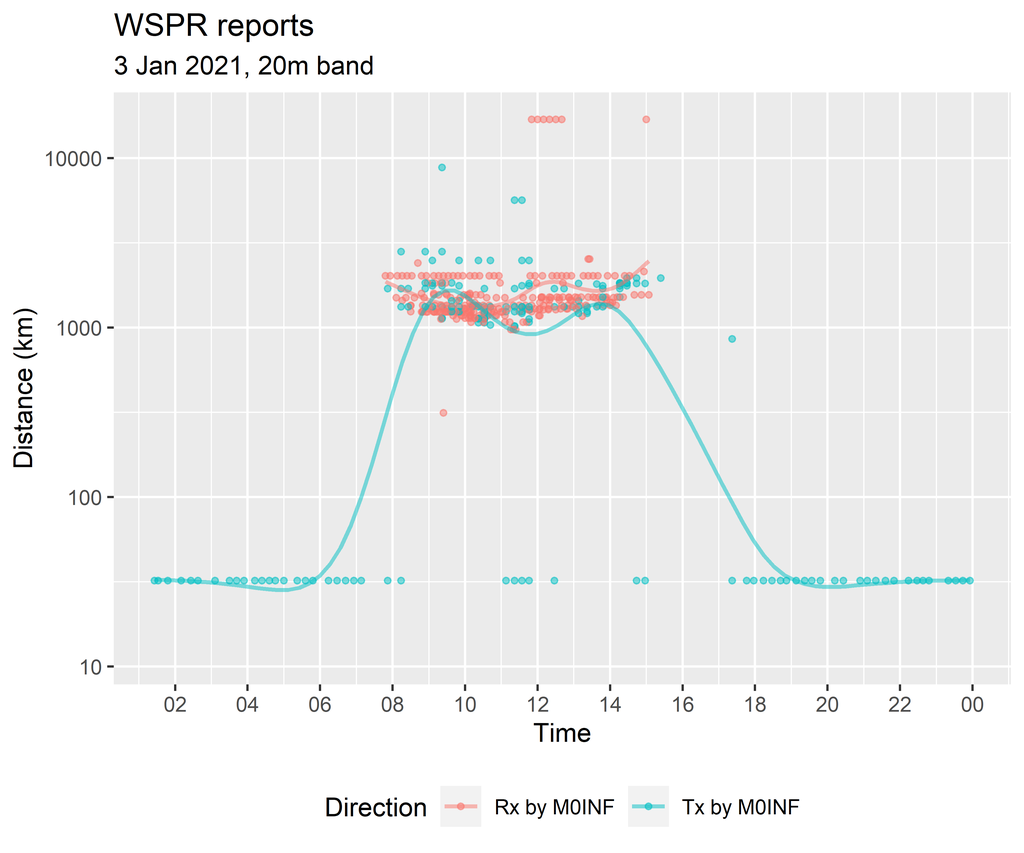

```r
the_dat_send_rec %>%
  ggplot(aes(wd_time, distance, colour = Direction)) +
  geom_point(alpha = 0.5, size = 1) +
  stat_smooth(geom="line",
              alpha = 0.5, size = 0.8,
              method = "gam",
              formula = y ~ s(x, k = 25)) +
  labs(x = "Time", y = "Distance (km)",
       title = "WSPR reports",
       subtitle = "3 Jan 2021, 20m band") +
  scale_y_continuous(trans = "log10") +
  scale_x_datetime(date_breaks = "2 hour", date_labels = "%H") +
  theme(legend.position="bottom")
```

Which of those reports are over 5000 km?

```r
the_dat_send_rec %>%
  filter(distance > 5000) %>%
  group_by(CallSign, Reporter, distance) %>%
  summarise(Spots = n()) %>%
  arrange(desc(Spots)) %>%
  kable()
```

| CallSign | Reporter | distance | Spots |
| --- | --- | --- | --- |
| VK3MO | M0INF | 16880 | 7 |
| M0INF | KD2OM | 5635 | 2 |
| M0INF | PT2FHC | 8786 | 1 |

And which are under 100 km?

```r
the_dat_send_rec %>%
  filter(distance < 100) %>%
  group_by(CallSign, Reporter, distance) %>%
  summarise(Spots = n()) %>%
  arrange(desc(Spots)) %>%
  kable()
```

| CallSign | Reporter | distance | Spots |
| --- | --- | --- | --- |
| M0INF | GB0SNB/SDR | 32 | 58 |

## Try two days (now there’s more data)

```r
two_day_send_receive <- dbSendQuery(db_con,
  "SELECT * FROM spots
   WHERE (\"CallSign\" = 'M0INF' OR \"Reporter\" = 'M0INF')
   AND wd_time >= '2021-01-03T00:00:00Z'
   AND wd_time <  '2021-01-05T00:00:00Z';")
```

```r
two_dat_send_rec <- dbFetch(two_day_send_receive)
dbClearResult(two_day_send_receive)
```

```r
two_dat_send_rec <- two_dat_send_rec %>%
  mutate(Direction = ifelse(Reporter == "M0INF",
                            "Rx by M0INF",
                            "Tx by M0INF"))
```

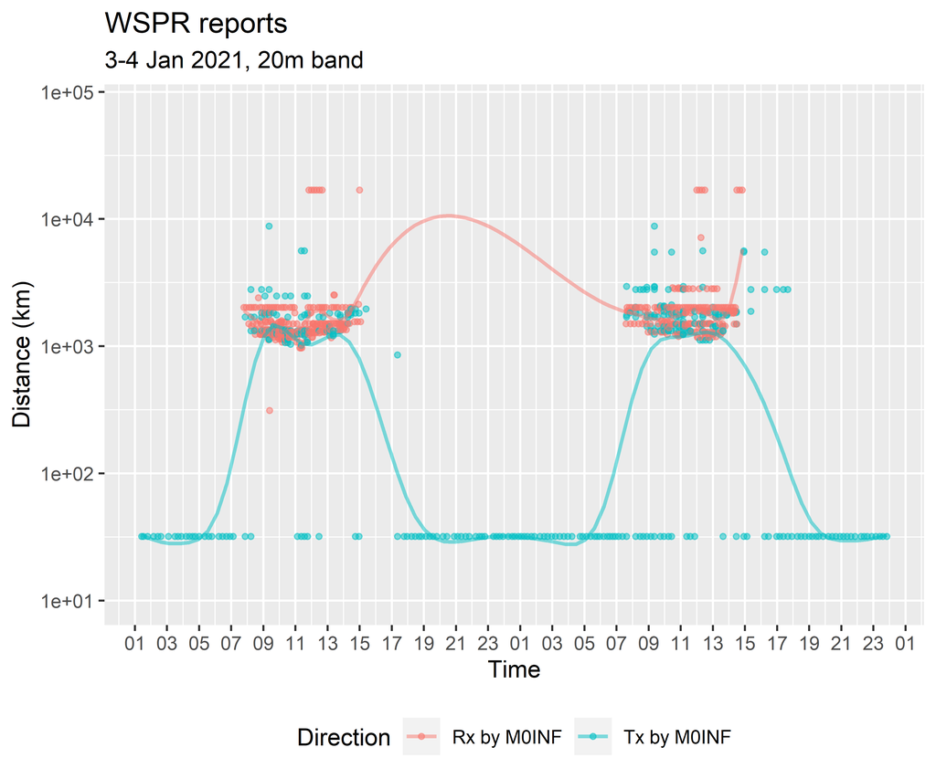

```r
two_dat_send_rec %>%
  ggplot(aes(wd_time, distance, colour = Direction)) +
  geom_point(alpha = 0.5, size = 1) +
  stat_smooth(geom="line",
              alpha = 0.5, size = 0.8,
              method = "gam",
              formula = y ~ s(x, k = 25)) +
  labs(x = "Time", y = "Distance (km)",
       title = "WSPR reports",
       subtitle = "3-4 Jan 2021, 20m band") +
  scale_y_continuous(trans = "log10") +
  scale_x_datetime(date_breaks = "2 hour", date_labels = "%H") +
  theme(legend.position="bottom")
```

The red curve doesn’t make sense since there is missing data which should essentially be zero. For now, let’s remove it…

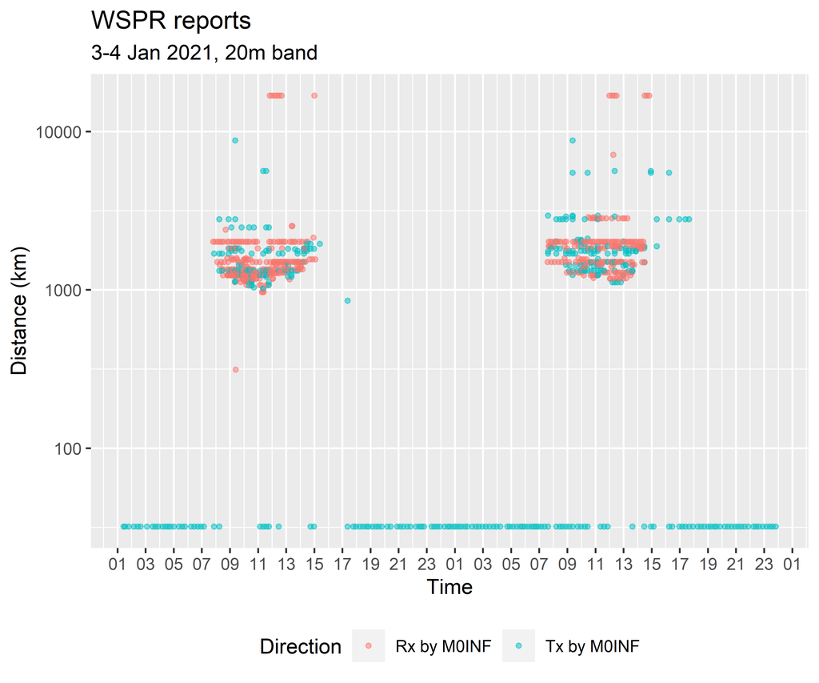

```r
two_dat_send_rec %>%
  ggplot(aes(wd_time, distance, colour = Direction)) +
  geom_point(alpha = 0.5, size = 1) +
  labs(x = "Time", y = "Distance (km)",
       title = "WSPR reports",
       subtitle = "3-4 Jan 2021, 20m band") +
  scale_y_continuous(trans = "log10") +
  scale_x_datetime(date_breaks = "2 hour", date_labels = "%H") +
  theme(legend.position="bottom")
```

## Last hour sent/received from IO91

### Jitter plot

Here are the WSPR frequencies, for labeling the plot in a moment.

```r
wspr_bands <- tibble(
  MHz = c(
    0.136,
    0.4742,
    1.8366,
    3.5686,
    5.2872,
    5364.7,
    7.0386,
    10.1387,
    14.0956,
    18.1046,
    21.0946,
    24.9246,
    28.1246,
    50.293,
    70.091,
    144.489,
    432.300,
    1296.500
  ),
  m = 299.792458 / MHz,
  wavelength_text = ifelse(m >= 1,
                           paste0(round(m, 0), " m"),
                           paste0(round(
                             m * 100, 0
                           ), " cm"))
) %>%
  arrange(MHz)

wspr_bands %>% kable()
```

| MHz | m | wavelength_text |
| --- | --- | --- |
| 0.1360 | 2204.3563088 | 2204 m |
| 0.4742 | 632.2067862 | 632 m |
| 1.8366 | 163.2323086 | 163 m |
| 3.5686 | 84.0084229 | 84 m |
| 5.2872 | 56.7015543 | 57 m |
| 7.0386 | 42.5926261 | 43 m |
| 10.1387 | 29.5691221 | 30 m |
| 14.0956 | 21.2685134 | 21 m |
| 18.1046 | 16.5589109 | 17 m |
| 21.0946 | 14.2118105 | 14 m |
| 24.9246 | 12.0279747 | 12 m |
| 28.1246 | 10.6594390 | 11 m |
| 50.2930 | 5.9609182 | 6 m |
| 70.0910 | 4.2771891 | 4 m |
| 144.4890 | 2.0748462 | 2 m |
| 432.3000 | 0.6934824 | 69 cm |
| 1296.5000 | 0.2312321 | 23 cm |
| 5364.7000 | 0.0558824 | 6 cm |

Grab the data:

```r
last_whispers <- dbSendQuery(db_con,
  "SELECT * FROM spots
   WHERE (\"ReporterGrid\" LIKE 'IO91%'
          OR \"Grid\" LIKE 'IO91%')
   AND wd_time > NOW() - INTERVAL '1 hour';")
```

```r
the_dat <- dbFetch(last_whispers)
dbClearResult(last_whispers)
```

```r
nrow(the_dat)
```

```
## [1] 4299
```

Group into WSPR bands:

```r
joined_dat <- the_dat %>%
  difference_left_join(wspr_bands,
                       by = "MHz",
                       max_dist = 0.2,
                       distance_col = "dist_band_start") %>%
  mutate(MHz.y = as.factor(MHz.y))
```

Check how many kHz off the match is (also look for NAs):

```r
summary(joined_dat$dist_band_start*1000)
```

```
##    Min. 1st Qu.  Median    Mean 3rd Qu.    Max.
##   1.374   1.470   1.507   2.352   1.545  79.079
```

Plot:

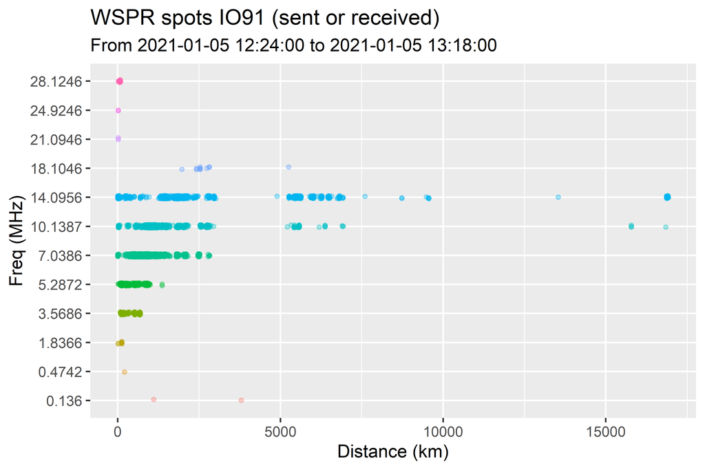

```r
joined_dat %>%
  ggplot(aes(distance, MHz.y, colour = MHz.y)) +
  geom_jitter(height = 0.05, alpha = 1/3, size = 1) +
  xlab("Distance (km)") +
  ylab("Freq (MHz)") +
  labs(title = "WSPR spots IO91 (sent or received)",
       subtitle = paste0("From ", min(the_dat$wd_time),
                         " to ", max(the_dat$wd_time))) +
  theme(legend.position = "none")
```

### Polar plot

Let’s do the same again but also showing the direction, for transmissions from IO91 only.

```r
tx_only <- joined_dat %>%
  filter(grepl(pattern = "IO91", x = Grid, ignore.case = TRUE))
```

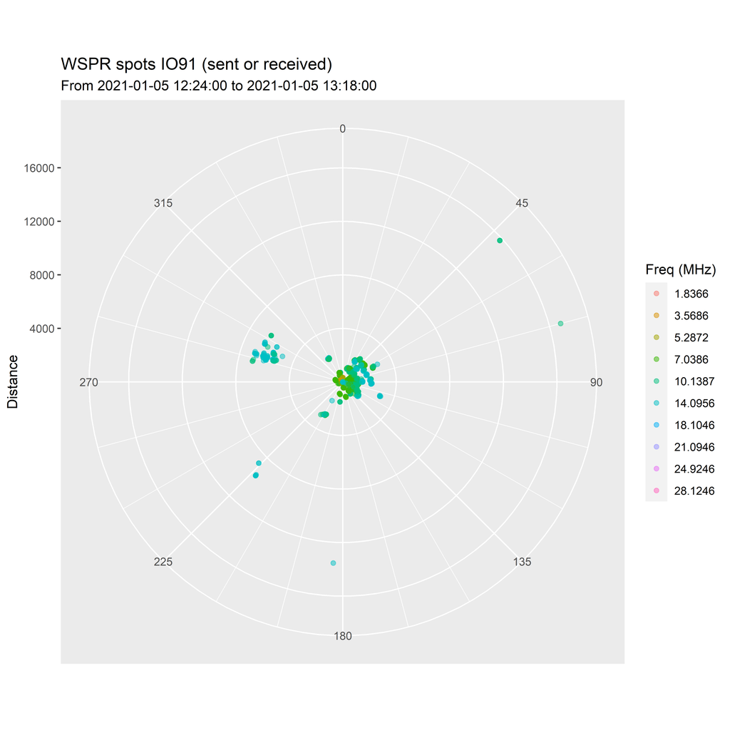

```r
linear_scale_polar <- tx_only %>%
  ggplot(aes(azimuth, distance, colour = MHz.y)) +
  geom_point(alpha = 0.5) +
  labs(
    title = "WSPR spots IO91 (sent or received)",
    subtitle = paste0("From ", min(the_dat$wd_time),
                      " to ", max(the_dat$wd_time)),
    colour = "Freq (MHz)",
    x = NULL,
    y = "Distance"
  ) +
  scale_x_continuous(
    limits = c(0, 360),
    breaks = seq(0, 315, by = 45),
    minor_breaks = seq(0, 360, by = 15)
  ) +
  coord_polar()

linear_scale_polar
```

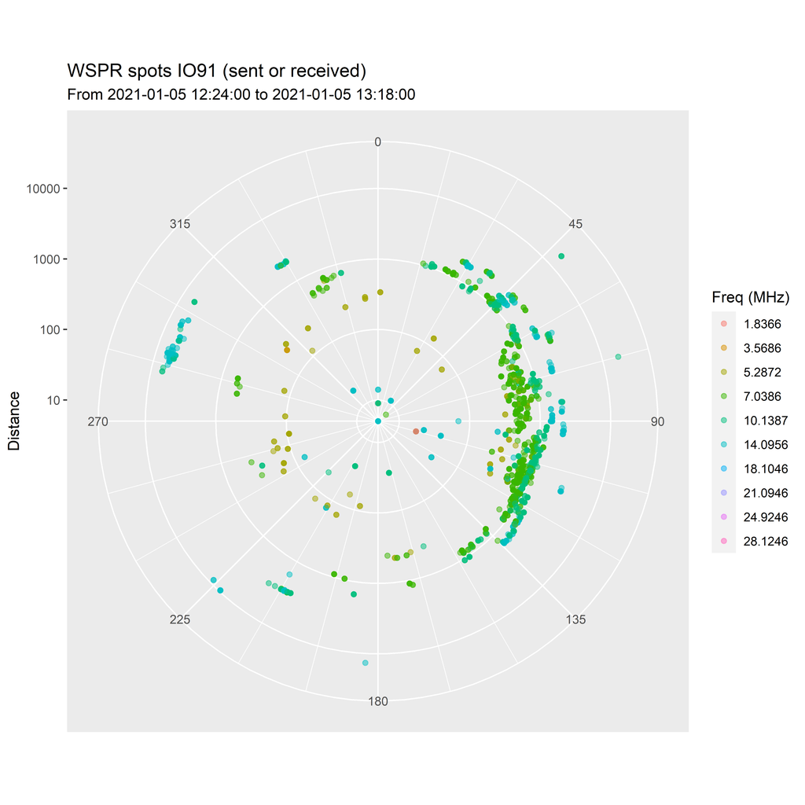

```r
linear_scale_polar +
  scale_y_continuous(trans = "log10")
```

```r
tx_only %>%
  filter(distance > 8000) %>%
  select(CallSign, Reporter, distance, azimuth)
```

```
##    CallSign Reporter distance azimuth
## 1     G8MCD   PY2SDR     9549     223
## 2    2E0GTD   VK4BAP    15789      48
## 3     M0GBZ   PY2SDR     9563     223
## 4     M0GBZ    PY2GN     9563     223
## 5     G4LRP   PY2SDR     9484     223
## 6     G4LRP DP0GVN-1    13544     183
## 7     G4LRP   PT2FHC     8731     226
## 8     G8MCD   PY2SDR     9549     223
## 9    2E0GTD   VK3GED    16847      75
## 10    G4LRP   PT2FHC     8731     226
## 11   2E0GTD   VK4BAP    15789      48
## 12   2E0GTD   VK4BAP    15789      48
```